# Segundo Examen Parcial Modelaje de Enfermedades Infecciosas

Considera el sigueinte conjunto de ecuaciones diferenciales que describen una enfermedad infecciosa con individuos en tratamiento $T(t)$. Con $N(t)=S(t)+E(t)+I(t)+T(t)$

$$\dot S = \nu -\beta_1 \frac{SI}{N}- \mu
S$$
$$\dot E= \beta_1\frac{SI}{N} +
\beta_2 \frac{TI}{N}-(\mu +\kappa +r_1)E +pr_2I$$
$$\dot I = \kappa E-(r_2+\mu)I$$
$$\dot T = r_1E +qr_2I -\beta_2\frac{TI}{N}-\mu
T$$

1. Dibuja el esquema por compartimentos que representa este conjunto de ecuaciones.

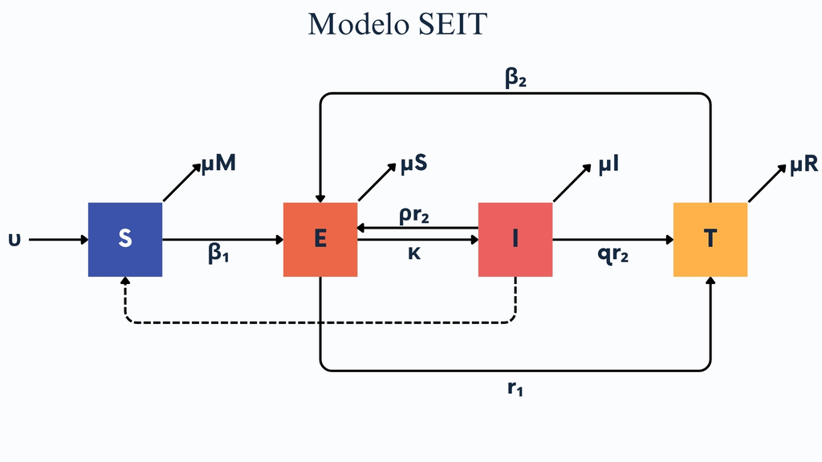

*Diagrama de compartimentos. Modelo SEIT*

2. Explica el significado de cada ecuación: es decir, explica el significado de cada término y cada parámetro. ¿Existen parámetros que están acotados, si es así indica el intervalo en donde pueden variar?
- $S$: Susceptibles
- $I$: Infectados
- $E$: Individuos en estado de latencia
- $R$: Recuperados
- $\mu$: Tasa de muerte
- $\nu:$ Tasa de nacimiento
- $\beta 1$: Tasa de transmisión de infectados a susceptibles
- $\beta 2$: Tasa de transmisión de invdiduos en tratamiento a susceptibles.
- $r_1$: Individuos en estado de latencia que pasan a tener un tratamiento.
- $r_2$: Individuos que salen del compartimennto de infectados.
- $p$: Fracción de individuos que pasan de infectados a estar en estado de latencia, es un valor acotado.
- $q$: Fracción de individuos que pasan de infectados a tener un tratamiento, es un valor acotado.
- $\kappa$: Tasa en la que un individuo pasa de estar en estado de latencia a infectado.
3. ¿Bajo qué condiciones la población se conservaría?

La población se conserva cuando la suma de las tasas de muerte de cada grupo ($\mu S$ + $\mu E$ + $\mu I$ + $\mu A$ + $\mu R$) es igual a $\nu$.

4. Encuentra, si existe, el punto de equilibrio *free-disease*
- $S=\nu -\mu S$
- $E=0$
- $I=0$
- $T=-mu T$

5. ¿Qué tipo de enfermedad puede estar describiendo? Justifica tu respuesta.

Desde mi perspectiva, el VIH/SIDA se ajusta al modelo SEIT. Los individuos Susceptibles que se exponen con un infectado, pueden tener periodos largos de latencia, los tratamientos de los infectados pueden también variar tanto en efectividad como en constancia.

6. Selecciona un conjunto de parámetros adecuados y resuelve numéricamente el sistema de ecuaciones diferenciales. Asegurate que tu solución alcance un punto de equilibrio.Discute tu resultado.

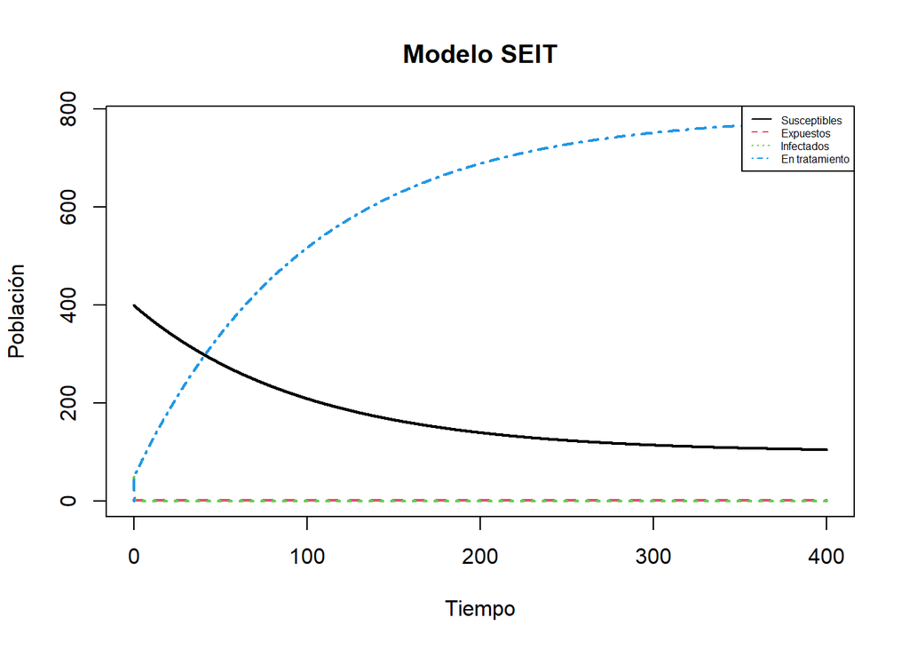

```r
SEIT <- function(t, state, parameters) {
  with(as.list(c(state, parameters)), {

   dS <- nu-(beta1*S*I)/(S+E+I+Tr)-mu*S
    dE <- (beta1*S*I)/(S+E+I+Tr) + (beta2*Tr*I)/(S+E+I+Tr) - (mu+kapa+r1)*E + p*r2
    dI <- kapa*E - (r2+mu)*I
    dTr <- r1*E + q*r2*I-(beta2*Tr*I)/(S+E+I+Tr) - mu*Tr

    list(c(dS, dE, dI, dTr))
  })
}

pars <- c(nu = 1, mu = 0.01, beta1 = 0.2, beta2 = 0.09, p = 0.8, q=0.2, r1 = 7, r2 = 12, kapa = 2)
condiciones_iniciales <- c(S=400, E=50, I=50, Tr=0)
tiempo <- seq(0, 400, by = 0.01)
out <- ode(condiciones_iniciales, tiempo, SEIT, pars)

matplot(out[ , 1], out[ , 2:5], type = "l", xlab = "Tiempo", ylab = "Población",
        main = "Modelo SEIT", lwd = 2)
legend("topright", c("Susceptibles", "Expuestos", "Infectados",  "En tratamiento"), col = 1:4, lty = 1:4, cex = 0.5)
```

**PROBLEMA 7. MODELO EPIDEMIOLÓGICO DE LA CDMX**

Considera el modelo que usó la CDMX para moniterear al inicio de la pandemia de COVID-19 los casos, los hospitalizados y muertes en dicha entidad. El modelo se encuentra [acá](https://modelo.covid19.cdmx.gob.mx/modelo-epidemico)

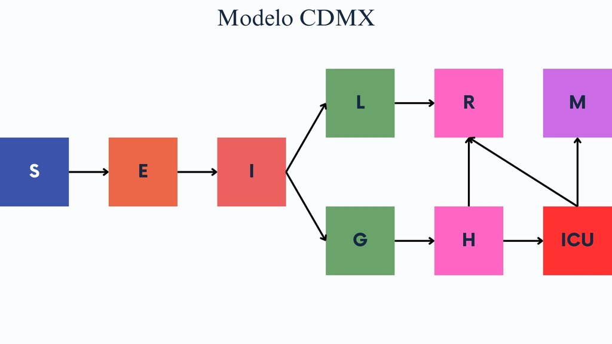

1. Explica el significado de cada ecuación: es decir, explica el significado de cada término y cada parámetro.
- $S$: Susceptibles
- $E$: Expuestos
- $I$: Infectados
- $L$: Contagiados con síntomas leves
- $G$: Contagiados con síntomas graves
- $H$: Hospitalizados
- $ICU$: Unidad de Terapia Intensiva
- $R$: Recuperados
- $M$: Decesos
- $N$: Población total susceptible.
- $D_{infect}$: Tiempo en el que es infeccioso un individuo.
- $D_{incub}$: Tiempo de incubación del virus en los individuos.
- $P_{grave}$: Tasa en la que son hospitalizados las personas con enfermedad.
- $D_{RL}$: Tiempo de recuperación de los individuos con síntomas leves.
- $D_{hosp}$: Tiempo entre la presencia de los síntomas y la hospitalización de individuos con síntomas graves.
- $P_{ICU}$: Tasa de individuos que ingresan a terapia intensiva.
- $D_{RH}$: Tiempo entre la hospitalización de casos graves no en terapia intensiva y la recuperación.
- $P_M$: Tasa de letalidad de la población en general.
- $D_{ICU}$: Tiempo entre la hospitalización de casos e ingreso a terapia intensiva.
- $D_{RICU}$: Tiempo entre el ingreso a terapia intensiva y recuperación.
- $D_M$: Tiempo de ingreso a terapia intensiva y deceso.
2. ¿La población se conserva?

3. Encuentra, si existe, el punto de equilibrio *free-disease*

Para este modelo, el *free-disease* se alcanza cuando $R_0 < 1$

4. Usa los parámetros de parámetros que sugieren y resuelve numéricamente el sistema de ecuaciones diferenciales. Asegurate que tu solución alcance un punto de equilibrio.Discute tu resultado.

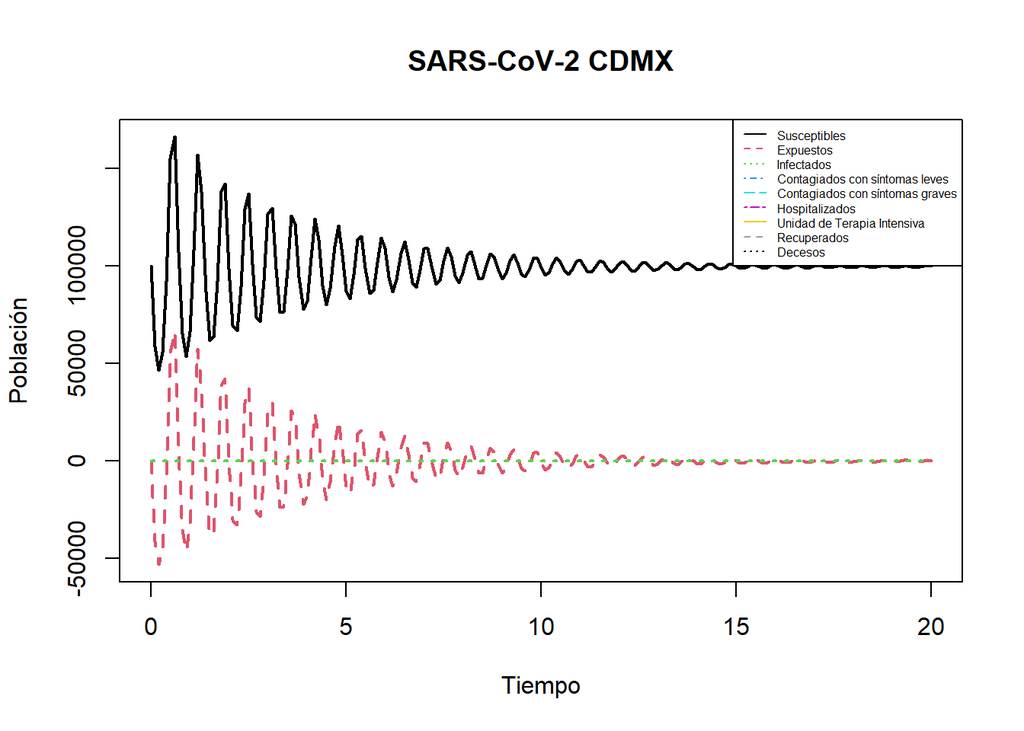

```r
SARS <- function(t, state, parameters) {
  with(as.list(c(state, parameters)), {

    dS <- -(R0 / Dinfect)*I*S
    dE <- -(R0 / Dinfect)*I*S - (1/Dincub)*E
    dI <- (1 / Dincub)*E - (1 / Dinfect)*I
    dL <- (1 - Pgrave) * (1 / Dinfect)*I - (1/DRL)*L
    dG <- Pgrave* (1 / Dinfect)*I- (1 / Dhosp)*G
    dH <- (1 / Dhosp)*G - (1 - PICU) * (1 / DRH)*H - PICU *(1 / DICU)*H
    dICU <- PICU*(1 / DICU)*H - (1 - PM)*(1 / DRICU) * ICU - PM*(1 / DM)*ICU
    dR <- (1 / DRL)*L + (1 - PICU) * (1 / DRH)*H + (1-PM)*(1 / DRICU)*ICU
    dM <- PM*(1 / DM)*ICU

    list(c(dS, dE, dI, dL, dG, dH, dICU, dR, dM))
  })
}

pars <- c(Dinfect=2.9, Dincub=5.2, Pgrave=0.1380, DRL=14, Dhosp=4, PICU=0.05, DRH=12, PM=0.03, DICU=1, DRICU=7, DM=8, R0=2.83)
condiciones_iniciales <- c(S=100000, E=10, I=100, L=0, G=0, H=0, ICU=0, R=0, M=0)
tiempo <- seq(0, 20, by = 0.1)
out <- ode(condiciones_iniciales, tiempo, SARS, pars)

matplot(out[ , 1], out[ , 2:4], type = "l", xlab = "Tiempo", ylab = "Población",
        main = "SARS-CoV-2 CDMX", lwd = 2)
legend("topright", c("Susceptibles", "Expuestos", "Infectados", "Contagiados con síntomas leves", "Contagiados con síntomas graves", "Hospitalizados", "Unidad de Terapia Intensiva", "Recuperados", "Decesos"), col = 1:9,lty=1:9,cex=0.5)
```

Los movimientos ondulatorios de la gráfica me hacen pensar en los brotes que se van dando en lapsos tales, hasta que la enfermedad se vuelve endémica (eso sin contar la mutación del virus en nuevas variantes)

5. ¿Qué modificaciones se te ocurren que podrían implementarse para mejorar ese modelo?

Contemplaría la tasa de nacimiento o entrada de población susceptible por cualquier medio y consideraría una tasa de muerte para cada grupo con la “etiqueta” de que sean causas de muerte naturales o causadas por la enfermedad.

**EJERCICIO 6. TIDIVERSE: DATOS COVID MÉXICO Y PINGÜINOS**

Utiliza la librería `palmerpenguins` par el siguiente problema. Carga los datos, incluidos en esa librería, `penguins` a partir de ello escribe un script en R que resuelva lo siguiente:

```r
library(palmerpenguins)
library(dplyr)
```

1. Filtra los pingüinos que pertenecen a la especie “Adelie” y tienen un peso corporal mayor a 3500 gramos.

```r
adeli <- penguins %>%
  filter(species == "Adelie", body_mass_g > 3500)

# Muestra los resultados
adeli
```

```
## # A tibble: 92 × 8
##    species island    bill_length_mm bill_depth_mm flipper_length_mm body_mass_g
##    <fct>   <fct>              <dbl>         <dbl>             <int>       <int>
##  1 Adelie  Torgersen           39.1          18.7               181        3750
##  2 Adelie  Torgersen           39.5          17.4               186        3800
##  3 Adelie  Torgersen           39.3          20.6               190        3650
##  4 Adelie  Torgersen           38.9          17.8               181        3625
##  5 Adelie  Torgersen           39.2          19.6               195        4675
##  6 Adelie  Torgersen           42            20.2               190        4250
##  7 Adelie  Torgersen           37.8          17.3               180        3700
##  8 Adelie  Torgersen           38.6          21.2               191        3800
##  9 Adelie  Torgersen           34.6          21.1               198        4400
## 10 Adelie  Torgersen           36.6          17.8               185        3700
## # ℹ 82 more rows
## # ℹ 2 more variables: sex <fct>, year <int>
```

2. Crea una nueva columna llamada “bmi” (Body Mass Index) que represente el índice de masa corporal usando la fórmula:
   $$BMI = peso (kg) / (altura (m))^2$$
   . La altura está representada en centímetros en la base de datos, así que conviértela a metros.

```r
pen_bmi <- penguins %>%
  mutate(
    body_mass_kg = body_mass_g / 1000,    # Convertir el peso a kilogramos
    height_m = flipper_length_mm / 1000,  # Convertir la longitud de aleta a metros
    bmi = body_mass_kg / (height_m ^ 2)   # Calcular el índice de masa corporal (BMI)
  )

# Mostrar los primeros resultados
pen_bmi
```

```
## # A tibble: 344 × 11
##    species island    bill_length_mm bill_depth_mm flipper_length_mm body_mass_g
##    <fct>   <fct>              <dbl>         <dbl>             <int>       <int>
##  1 Adelie  Torgersen           39.1          18.7               181        3750
##  2 Adelie  Torgersen           39.5          17.4               186        3800
##  3 Adelie  Torgersen           40.3          18                 195        3250
##  4 Adelie  Torgersen           NA            NA                  NA          NA
##  5 Adelie  Torgersen           36.7          19.3               193        3450
##  6 Adelie  Torgersen           39.3          20.6               190        3650
##  7 Adelie  Torgersen           38.9          17.8               181        3625
##  8 Adelie  Torgersen           39.2          19.6               195        4675
##  9 Adelie  Torgersen           34.1          18.1               193        3475
## 10 Adelie  Torgersen           42            20.2               190        4250
## # ℹ 334 more rows
## # ℹ 5 more variables: sex <fct>, year <int>, body_mass_kg <dbl>,
## #   height_m <dbl>, bmi <dbl>
```

3. Agrupa los datos por la especie y calcula la media del índice de masa corporal (bmi) para cada especie.

```r
bmi_esp <- pen_bmi %>%
  group_by(species) %>%
  summarise(mean_bmi = mean(bmi, na.rm = TRUE))

# Mostrar los resultados
bmi_esp
```

```
## # A tibble: 3 × 2
##   species   mean_bmi
##   <fct>        <dbl>
## 1 Adelie       103.
## 2 Chinstrap     97.3
## 3 Gentoo       107.
```

4. Ordena las especies por la media del índice de masa corporal de manera descendente.

```r
  bmi_esp_des <- pen_bmi %>%
  group_by(species) %>%
  summarise(mean_bmi = mean(bmi, na.rm = TRUE)) %>%
  arrange(desc(mean_bmi))

# Mostrar los resultados
bmi_esp_des
```

```
## # A tibble: 3 × 2
##   species   mean_bmi
##   <fct>        <dbl>
## 1 Gentoo       107.
## 2 Adelie       103.
## 3 Chinstrap     97.3
```

5. Realiza un diagrama de barras de la media del índice de masa corporal por especie.

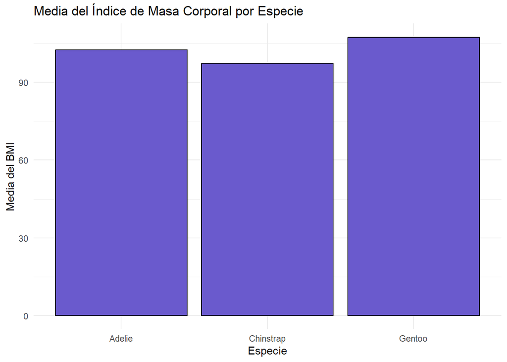

```r
library(ggplot2)

bmi_mean_esp <- pen_bmi %>%
  group_by(species) %>%
  summarise(mean_bmi = mean(bmi, na.rm = TRUE))

# Crear el diagrama de barras
ggplot(bmi_esp_des, aes(x = species, y = mean_bmi)) +
  geom_bar(stat = "identity", fill = "slateblue", color = "black") +
  labs(title = "Media del Índice de Masa Corporal por Especie",
       x = "Especie",
       y = "Media del BMI") +
  theme_minimal()
```